# TP8 : CARTOGRAPHIE AVEC R

ALBERT ZINABA et DJERAKEI MISTALENGAR

2025-03-10

Connexion internet requise:

Les cartes interactives générées dans ce document utilisent des bibliothèques JavaScript (telles que leaflet) qui nécessitent une connexion Internet pour fonctionner correctement. Il faut être connecté à Internet pour visualiser les cartes interactives.

#### Installation et chargement des packages

```r
# Liste des packages nécessaires

packages <- c("sf", "ggplot2", "tmap", "leaflet", "RColorBrewer", "viridis",
              "viridisLite", "rnaturalearth", "readr", "haven", "utils",
              "dplyr", "ggspatial")

# Vérification et installation
invisible(lapply(packages, function(pkg) {
  if (!requireNamespace(pkg, quietly = TRUE)) {
    install.packages(pkg, quiet = TRUE)
  }
  if (!pkg %in% .packages()) {
    suppressMessages(library(pkg, character.only = TRUE))
  }
}))
```

```r
# Supprimer toutes les variables de l'environnement
rm(list = ls())
```

#### Introduction

Ce document R Markdown présente une analyse géospatiale des données de l’enquête EHCVM (Enquête harmonisée sur les Conditions de Vie des Ménages) au Burkina Faso. L’analyse est divisée en deux parties principales : la première partie se concentre sur la visualisation des données des ménages à différents niveaux administratifs (régions, départements, communes), tandis que la deuxième partie se concentre sur la création de cartes administratives du Burkina Faso à partir de fichiers shapefile.

# Partie I : Analyse des données des ménages

```r
# Chargement de la base

base <- haven::read_dta("../Donnees/EHCVM_HDX_Burkina.dta")
```

```r
#  Convertir toutes les variables `labelled` en `factor`
base <- base %>%
  mutate(across(where(is.labelled), ~ as_factor(.)))

# Aperçu dela base
head(base)
```

```
## # A tibble: 6 × 43
##     hhid grappe menage vague hhweight s00q00  s00q01 s00q02 s00q03 s00q04 s00q05
##    <dbl>  <dbl>  <dbl> <dbl>    <dbl> <fct>   <fct>  <fct>  <chr>  <fct>  <chr>
## 1 586005    586      5     2      439 Burkin… Boucl… Kossi  Djiba… Rural  Djiba…
## 2 586028    586     28     2      439 Burkin… Boucl… Kossi  Djiba… Rural  Djiba…
## 3 586043    586     43     2      439 Burkin… Boucl… Kossi  Djiba… Rural  Djiba…
## 4 586044    586     44     2      439 Burkin… Boucl… Kossi  Djiba… Rural  Djiba…
## 5 586052    586     52     2      439 Burkin… Boucl… Kossi  Djiba… Rural  Djiba…
## 6 586082    586     82     2      439 Burkin… Boucl… Kossi  Djiba… Rural  Djiba…
## # ℹ 32 more variables: s00q07a <fct>, s00q07b <fct>, s00q07c <fct>,
## #   s00q07d <fct>, s00q07d2 <fct>, s00q22 <dbl>, s00q23a <chr>, s00q24a <chr>,
## #   s00q25a <chr>, s00q23b <chr>, s00q24b <chr>, s00q25b <chr>, s00q08 <fct>,
## #   s00q27 <fct>, s00q28 <fct>, GPS__Latitude <dbl>, GPS__Longitude <dbl>,
## #   ADM3_FR <chr>, ADM3_PCODE <chr>, ADM3_REF <chr>, ADM3ALT1_FR <dbl>,
## #   ADM3ALT2_FR <dbl>, ADM2_FR <chr>, ADM2_PCODE <chr>, ADM1_FR <chr>,
## #   ADM1_PCODE <chr>, ADM0_FR <chr>, ADM0_PCODE <chr>, DATE <dttm>, …
```

Les valeurs manquantes dans les colonnes de coordonnées (latitude et longitude) sont vérifiées et les lignes correspondantes sont supprimées. Les variables étiquetées sont converties en facteurs pour faciliter l’analyse.

```r
# Vérifier les valeurs manquantes dans les colonnes de coordonnées

sum(is.na(base$GPS__Longitude))  # Nombre de valeurs manquantes dans GPS__Longitude
```

```
## [1] 48
```

```r
sum(is.na(base$GPS__Latitude))   # Nombre de valeurs manquantes dans GPS__Latitude
```

```
## [1] 48
```

```r
# Option 1 : Supprimer les lignes avec des coordonnées manquantes
base_clean <- base %>%
  filter(!is.na(GPS__Longitude) & !is.na(GPS__Latitude))


# Convertir en objet géospatial après nettoyage
base_sf <- st_as_sf(base_clean, coords = c("GPS__Longitude", "GPS__Latitude"), crs = 4326)

# Aperçu de l'objet géospatial
head(base_sf)
```

```
## Simple feature collection with 6 features and 41 fields
## Geometry type: POINT
## Dimension:     XY
## Bounding box:  xmin: -4.168 ymin: 13.122 xmax: -4.163 ymax: 13.127
## Geodetic CRS:  WGS 84
## # A tibble: 6 × 42
##     hhid grappe menage vague hhweight s00q00  s00q01 s00q02 s00q03 s00q04 s00q05
##    <dbl>  <dbl>  <dbl> <dbl>    <dbl> <fct>   <fct>  <fct>  <chr>  <fct>  <chr>
## 1 586005    586      5     2      439 Burkin… Boucl… Kossi  Djiba… Rural  Djiba…
## 2 586028    586     28     2      439 Burkin… Boucl… Kossi  Djiba… Rural  Djiba…
## 3 586043    586     43     2      439 Burkin… Boucl… Kossi  Djiba… Rural  Djiba…
## 4 586044    586     44     2      439 Burkin… Boucl… Kossi  Djiba… Rural  Djiba…
## 5 586052    586     52     2      439 Burkin… Boucl… Kossi  Djiba… Rural  Djiba…
## 6 586082    586     82     2      439 Burkin… Boucl… Kossi  Djiba… Rural  Djiba…
## # ℹ 31 more variables: s00q07a <fct>, s00q07b <fct>, s00q07c <fct>,
## #   s00q07d <fct>, s00q07d2 <fct>, s00q22 <dbl>, s00q23a <chr>, s00q24a <chr>,
## #   s00q25a <chr>, s00q23b <chr>, s00q24b <chr>, s00q25b <chr>, s00q08 <fct>,
## #   s00q27 <fct>, s00q28 <fct>, ADM3_FR <chr>, ADM3_PCODE <chr>,
## #   ADM3_REF <chr>, ADM3ALT1_FR <dbl>, ADM3ALT2_FR <dbl>, ADM2_FR <chr>,
## #   ADM2_PCODE <chr>, ADM1_FR <chr>, ADM1_PCODE <chr>, ADM0_FR <chr>,
## #   ADM0_PCODE <chr>, DATE <dttm>, VALIDON <dttm>, VALIDTO <dbl>, …
```

Visualisation des données par niveau administratif.

#### Agrégation par régions

```r
regions <- base_sf %>%
  group_by(ADM1_FR) %>%
  summarise(n = n()) %>%
  st_centroid()  # Calculer les centroïdes pour placer les points

# Palette de couleurs pour les régions
pal_regions <- colorNumeric("viridis", regions$n)

# Carte dynamique par département
leaflet(regions) %>%
  addTiles() %>%  # Ajouter un fond de carte OpenStreetMap
  addCircleMarkers(
    radius = ~sqrt(n) * 2,  # Taille proportionnelle au nombre de ménages
    color = ~pal_regions(n),  # Couleur en fonction du nombre de ménages
    stroke = FALSE,  # Pas de contour
    fillOpacity = 0.8,  # Opacité des points
    popup = ~paste(  # Popup avec des informations supplémentaires
      "<b>Régions:</b> ", ADM1_FR, "<br>",
      "<b>Nombre de ménages:</b> ", n
    )
  ) %>%
  addLegend(  # Ajouter une légende
    position = "bottomright",
    pal = pal_regions,
    values = ~n,
    title = "Nombre de ménages"
  ) %>%
  setView(lng = -1.5, lat = 12.5, zoom = 6 )%>% addScaleBar()  # Centrer la carte sur le Burkina Faso
```

[interactive chart not shown]

#### Agrégation par département

```r
departements <- base_sf %>%
  group_by(ADM2_FR) %>%
  summarise(n = n()) %>%
  st_centroid()  # Calculer les centroïdes pour placer les points

# Palette de couleurs pour les départements
pal_departements <- colorNumeric("viridis", departements$n)

# Carte dynamique par département
leaflet(departements) %>%
  addTiles() %>%  # Ajouter un fond de carte OpenStreetMap
  addCircleMarkers(
    radius = ~sqrt(n) * 2,  # Taille proportionnelle au nombre de ménages
    color = ~pal_departements(n),  # Couleur en fonction du nombre de ménages
    stroke = FALSE,  # Pas de contour
    fillOpacity = 0.8,  # Opacité des points
    popup = ~paste(  # Popup avec des informations supplémentaires
      "<b>Département:</b> ", ADM2_FR, "<br>",
      "<b>Nombre de ménages:</b> ", n
    )
  ) %>%
  addLegend(  # Ajouter une légende
    position = "bottomright",
    pal = pal_departements,
    values = ~n,
    title = "Nombre de ménages"
  ) %>%
  setView(lng = -1.5, lat = 12.5, zoom = 6 )%>% addScaleBar()  # Centrer la carte sur le Burkina Faso
```

[interactive chart not shown]

#### Agrégation par commune

```r
communes <- base_sf %>%
  group_by(ADM3_FR) %>%
  summarise(n = n()) %>%
  st_centroid()  # Calculer les centroïdes pour placer les points

# Palette de couleurs pour les communes
pal_communes <- colorNumeric("plasma", communes$n)

# Carte dynamique par commune
leaflet(communes) %>%
  addTiles() %>%  # Ajouter un fond de carte OpenStreetMap
  addCircleMarkers(
    radius = ~sqrt(n) * 2,  # Taille proportionnelle au nombre de ménages
    color = ~pal_communes(n),  # Couleur en fonction du nombre de ménages
    stroke = FALSE,  # Pas de contour
    fillOpacity = 0.8,  # Opacité des points
    popup = ~paste(  # Popup avec des informations supplémentaires
      "<b>Commune:</b> ", ADM3_FR, "<br>",
      "<b>Nombre de ménages:</b> ", n
    )
  ) %>%
  addLegend(  # Ajouter une légende
    position = "bottomright",
    pal = pal_communes,
    values = ~n,
    title = "Nombre de ménages"
  ) %>%
  setView(lng = -1.5, lat = 12.5, zoom = 6) %>% addScaleBar()  # Centrer la carte sur le Burkina Faso
```

[interactive chart not shown]

#### Carte par milieu de résidence (urbain/rural - s00q04).

Cette carte montre la répartition des ménages entre urbain et rural.

```r
# Vérification et nettoyage
base_sf <- base_sf %>% filter(!is.na(s00q04))

# Création d'une palette de couleurs
pal_milieu <- colorFactor(c("blue", "green"), domain = c("Rural", "Urbain"))

# Carte interactive
leaflet(base_sf) %>%
  addTiles() %>%
  addCircleMarkers(
    color = ~pal_milieu(s00q04),
    radius = 3,
    stroke = FALSE,
    fillOpacity = 0.8,
    popup = ~paste("Milieu:", ifelse(s00q04 == 1, "Urbain", "Rural"))
  ) %>%
  addLegend(
    position = "bottomright",
    pal = pal_milieu,
    values = ~s00q04,
    labels = c("Urbain", "Rural"),
    title = "Milieu de résidence"
  )
```

[interactive chart not shown]

#### Carte des types de ménages (s00q07a).

Cette carte affiche les types de ménages présents dans la base de données.

```r
# Vérification et nettoyage
base_sf <- base_sf %>% filter(!is.na(s00q07a))

# Palette de couleurs pour les types de ménages
pal_type_menage <- colorFactor("viridis", domain = unique(base_sf$s00q07a))

# Carte interactive
leaflet(base_sf) %>%
  addTiles() %>%
  addCircleMarkers(
    color = ~pal_type_menage(s00q07a),
    radius = 3,
    stroke = FALSE,
    fillOpacity = 0.8,
    popup = ~paste("Type de ménage:", s00q07a)
  ) %>%
  addLegend(
    position = "bottomright",
    pal = pal_type_menage,
    values = ~s00q07a,
    title = "Type de ménage"
  )
```

[interactive chart not shown]

#### Carte des ménages récemment installés (s00q07b).

Cette carte montre les ménages vivant dans la localité depuis moins de 5 ans.

```r
# Vérification et nettoyage
base_sf <- base_sf %>% filter(!is.na(s00q07b))

# Palette de couleurs
pal_migration <- colorFactor(c("red", "green"), domain = c("Oui", "Non"))  # 1 = Oui, 2 = Non

# Carte interactive
leaflet(base_sf) %>%
  addTiles() %>%
  addCircleMarkers(
    color = ~pal_migration(s00q07b),
    radius = 3,
    stroke = FALSE,
    fillOpacity = 0.8,
    popup = ~paste("Installation récente:", ifelse(s00q07b == 1, "Oui", "Non"))
  ) %>%
  addLegend(
    position = "bottomright",
    pal = pal_migration,
    values = ~s00q07b,
    labels = c("Oui", "Non"),
    title = "Moins de 5 ans dans la localité"
  )
```

[interactive chart not shown]

Carte des ménages ayant fui un conflit ou une catastrophe (s00q07c) Cette carte montre les ménages ayant quitté leur ancienne localité à cause d’un conflit ou d’une catastrophe naturelle.

```r
# Vérification et nettoyage
base_sf <- base_sf %>% filter(!is.na(s00q07c))

# Palette de couleurs
pal_conflit <- colorFactor(c("green", "red"), domain = c("Oui", "Non"))  # 1 = Oui, 2 = Non

# Carte interactive
leaflet(base_sf) %>%
  addTiles() %>%
  addCircleMarkers(
    color = ~pal_conflit(s00q07c),
    radius = 3,
    stroke = FALSE,
    fillOpacity = 0.8) %>%
  addLegend(
    position = "bottomright",
    pal = pal_conflit,
    values = ~s00q07c,
    labels = c("Oui", "Non"),
    title = "Départ pour conflit/catastrophe"
  )
```

[interactive chart not shown]

Carte des ménages ayant participé aux enquêtes précédentes (s00q07d2) Cette carte identifie les ménages qui ont déjà été interviewés dans une enquête antérieure.

```r
# Vérification et nettoyage
base_sf <- base_sf %>% filter(!is.na(s00q07d2))

# Palette de couleurs
pal_ancien_menage <- colorFactor(c("purple", "orange"), domain = c("Oui", "Non"))

# Carte interactive
leaflet(base_sf) %>%
  addTiles() %>%
  addCircleMarkers(
    color = ~pal_ancien_menage(s00q07d2),
    radius = 3,
    stroke = FALSE,
    fillOpacity = 0.8) %>%
  addLegend(
    position = "bottomright",
    pal = pal_ancien_menage,
    values = ~s00q07d2,
    labels = c("Oui", "Non"),
    title = "Interviewé en 2018/2019"
  )
```

[interactive chart not shown]

Carte des résultats des interviews (s00q08) Cette carte permet de visualiser le statut des interviews réalisées.

```r
# Recoder correctement les modalities

base_sf$s00q08 <- recode(base_sf$s00q08,
                         "Rempli, mÃ©nage sÃ©lectionnÃ©" = "Ménage sélectionné",
                         "Rempli, mÃ©nage de remplacement" = "Ménage de remplacement")
```

```r
# Vérification et nettoyage
base_sf <- base_sf %>% filter(!is.na(s00q08))

# Palette de couleurs
pal_resultat <- colorFactor("plasma", domain = unique(base_sf$s00q08))

# Carte interactive
leaflet(base_sf) %>%
  addTiles() %>%
  addCircleMarkers(
    color = ~pal_resultat(s00q08),
    radius = 3,
    stroke = FALSE,
    fillOpacity = 0.8,
    popup = ~paste("Résultat de l'interview:", s00q08)
  ) %>%
  addLegend(
    position = "bottomright",
    pal = pal_resultat,
    values = ~s00q08,
    title = "Résultat de l'interview"
  )
```

[interactive chart not shown]

#### Carte croisant la migration récente (s00q07b) et la raison du départ (s00q07c).

L’objectif est de voir si les ménages récemment installés l’ont fait à cause de conflits ou de catastrophes naturelles.

```r
# Création d'une variable combinée pour croiser les deux variables (migration récente et raison du départ)

base_sf <- base_sf %>%
  mutate(
    migration_raison = case_when(
      s00q07b == "Oui" & s00q07c == "Oui" ~ "Migration récente - Conflit",
      s00q07b == "Oui" & s00q07c == "Non" ~ "Migration récente - Catastrophe naturelle",
      s00q07b == "Non" & s00q07c == "Oui" ~ "Migration ancienne - Conflit",
      s00q07b == "Non" & s00q07c == "Non" ~ "Migration ancienne - Catastrophe naturelle",
      TRUE ~ "Inconnu"
    ),
    migration_raison = factor(migration_raison, levels = c(
      "Migration récente - Conflit", "Migration récente - Catastrophe naturelle",
      "Migration ancienne - Conflit", "Migration ancienne - Catastrophe naturelle",
      "Inconnu"
    ))
  )

# Vérification de la répartition des catégories
print(table(base_sf$migration_raison))  # Affiche la distribution des catégories
```

```
##
##                Migration récente - Conflit
##                                        244
##  Migration récente - Catastrophe naturelle
##                                       1059
##               Migration ancienne - Conflit
##                                          0
## Migration ancienne - Catastrophe naturelle
##                                          0
##                                    Inconnu
##                                          0
```

```r
# Palette de couleurs avec des couleurs distinctes pour chaque combinaison
pal_migration_raison <- colorFactor(
  c("green", "blue", "orange", "red"),
  domain = levels(base_sf$migration_raison)  # Assurez-vous que chaque catégorie a une couleur distincte
)

# Carte interactive
leaflet(base_sf) %>%
  addTiles() %>%
  addCircleMarkers(
    color = ~pal_migration_raison(migration_raison),
    radius = 5,  # Ajustez la taille des points pour les rendre plus visibles
    stroke = FALSE,
    fillOpacity = 0.8,
    popup = ~paste("Migration et Raison du départ:", migration_raison)  # Afficher la catégorie au survol
  ) %>%
  addLegend(
    position = "bottomright",
    pal = pal_migration_raison,
    values = ~migration_raison,
    title = "Migration et Raisons du départ"
  )
```

[interactive chart not shown]

#### Carte croisant la participation aux enquêtes précédentes (s00q07d) et le résultat de l’interview (s00q08).

L’objectif est de voir si les ménages déjà interrogés en 2018/2019 ont des résultats d’interview différents dans cette enquête.

```r
# Vérification et nettoyage
base_sf <- base_sf %>% filter(!is.na(s00q07d), !is.na(s00q08))

# Création d'une variable combinée
base_sf <- base_sf %>%
  mutate(
    ancien_menage_resultat = paste("Enquête 2018/2019:", ifelse(s00q07d == 1, "Oui", "Non"), "- Résultat:", s00q08)
  )

# Palette de couleurs
pal_enquete_resultat <- colorFactor("plasma", domain = unique(base_sf$ancien_menage_resultat))

# Carte interactive
leaflet(base_sf) %>%
  addTiles() %>%
  addCircleMarkers(
    color = ~pal_enquete_resultat(ancien_menage_resultat),
    radius = 3,
    stroke = FALSE,
    fillOpacity = 0.8,
    popup = ~paste("Catégorie:", ancien_menage_resultat)
  ) %>%
  addLegend(
    position = "bottomright",
    pal = pal_enquete_resultat,
    values = ~ancien_menage_resultat,
    title = "Participation et Résultat"
  )
```

[interactive chart not shown]

#### Carte des proportions de ménages urbains/ruraux par région.

```r
# Vérification et nettoyage des données
base_sf <- base_sf %>% filter(!is.na(s00q04), !is.na(ADM1_FR))

# Agrégation des données : Nombre total de ménages par région et par milieu
base_agg <- base_sf %>%
  group_by(ADM1_FR, s00q04) %>%
  summarise(n = n(), .groups = "drop") %>%
  mutate(milieu = ifelse(s00q04 == 1, "Urbain", "Rural"))  # Conversion en texte

# Calcul des proportions (%)
base_agg <- base_agg %>%
  group_by(ADM1_FR) %>%
  mutate(total = sum(n), proportion = round((n / total) * 100, 1)) %>%
  ungroup()

# Création d'une palette de couleurs
pal_milieu_region <- colorFactor(c("blue", "green"), domain = base_agg$s00q04)

# Carte interactive avec proportions
leaflet(base_agg) %>%
  addTiles() %>%
  addCircleMarkers(
    lng = jitter(rep(-1.5, nrow(base_agg))),  # Position fictive (ajustez selon les coordonnées)
    lat = jitter(rep(12.5, nrow(base_agg))),  # Idéalement, utilisez les centroïdes des régions
    color = ~pal_milieu_region(s00q04),
    radius = ~sqrt(n) * 2,  # Taille proportionnelle au nombre de ménages
    stroke = FALSE,
    fillOpacity = 0.8,
    popup = ~paste0(
      "<b>Région:</b> ", ADM1_FR, "<br>",
      "<b>Milieu:</b> ", s00q04, "<br>",
      "<b>Ménages:</b> ", n, "<br>",
      "<b>Proportion:</b> ", proportion, " %"
    )
  ) %>%
  addLegend(
    position = "bottomright",
    pal = pal_milieu_region,
    values = ~s00q04,
    title = "Milieu (Urbain/Rural)"
  )
```

[interactive chart not shown]

#### Proportions de ménages urbains/ruraux par département.

```r
# Vérification et nettoyage des données
base_sf <- base_sf %>% filter(!is.na(s00q04), !is.na(ADM2_FR))

# Agrégation des données : Nombre total de ménages par département et par milieu
base_agg <- base_sf %>%
  group_by(ADM2_FR, s00q04) %>%
  summarise(n = n(), .groups = "drop")
# Calcul des proportions (%)
base_agg <- base_agg %>%
  group_by(ADM2_FR) %>%
  mutate(total = sum(n), proportion = round((n / total) * 100, 1)) %>%
  ungroup()

# Création d'une palette de couleurs
pal_milieu_departement <- colorFactor(c("red", "green"), domain = base_agg$s00q04)

# Carte interactive avec proportions
leaflet(base_agg) %>%
  addTiles() %>%
  addCircleMarkers(
    lng = jitter(rep(-1.5, nrow(base_agg))),  # Position fictive (ajustez selon les coordonnées)
    lat = jitter(rep(12.5, nrow(base_agg))),  # Idéalement, utilisez les centroïdes des départements
    color = ~pal_milieu_departement(s00q04),
    radius = ~sqrt(n) * 2,  # Taille proportionnelle au nombre de ménages
    stroke = FALSE,
    fillOpacity = 0.8,
    popup = ~paste0(
      "<b>Département:</b> ", ADM2_FR, "<br>",
      "<b>Milieu:</b> ", s00q04, "<br>",
      "<b>Ménages:</b> ", n, "<br>",
      "<b>Proportion:</b> ", proportion, " %"
    )
  ) %>%
  addLegend(
    position = "bottomright",
    pal = pal_milieu_departement,
    values = ~s00q04,
    title = "Milieu (Urbain/Rural)"
  )
```

[interactive chart not shown]

# Partie II : Cartes administratives du Burkina Faso

```r
#Charger les fichiers pour les cartes

shapefile_pays<- sf::st_read("../Donnees/BFA_adm/BFA_adm0.shp")
shapefile_regions <- st_read("../Donnees/BFA_adm/BFA_adm1.shp")
shapefile_provinces <- st_read("../Donnees/BFA_adm/BFA_adm2.shp")
shapefile_communes<- st_read("../Donnees/BFA_adm/BFA_adm3.shp")
# Verification des noms
colnames(shapefile_pays)
```

```
##  [1] "ID_0"       "ISO"        "NAME_0"     "OBJECTID_1" "ISO3"
##  [6] "NAME_ENGLI" "NAME_ISO"   "NAME_FAO"   "NAME_LOCAL" "NAME_OBSOL"
## [11] "NAME_VARIA" "NAME_NONLA" "NAME_FRENC" "NAME_SPANI" "NAME_RUSSI"
## [16] "NAME_ARABI" "NAME_CHINE" "WASPARTOF"  "CONTAINS"   "SOVEREIGN"
## [21] "ISO2"       "WWW"        "FIPS"       "ISON"       "VALIDFR"
## [26] "VALIDTO"    "POP2000"    "SQKM"       "POPSQKM"    "UNREGION1"
## [31] "UNREGION2"  "DEVELOPING" "CIS"        "Transition" "OECD"
## [36] "WBREGION"   "WBINCOME"   "WBDEBT"     "WBOTHER"    "CEEAC"
## [41] "CEMAC"      "CEPLG"      "COMESA"     "EAC"        "ECOWAS"
## [46] "IGAD"       "IOC"        "MRU"        "SACU"       "UEMOA"
## [51] "UMA"        "PALOP"      "PARTA"      "CACM"       "EurAsEC"
## [56] "Agadir"     "SAARC"      "ASEAN"      "NAFTA"      "GCC"
## [61] "CSN"        "CARICOM"    "EU"         "CAN"        "ACP"
## [66] "Landlocked" "AOSIS"      "SIDS"       "Islands"    "LDC"
## [71] "geometry"
```

```r
colnames(shapefile_regions)
```

```
##  [1] "ID_0"      "ISO"       "NAME_0"    "ID_1"      "NAME_1"    "TYPE_1"
##  [7] "ENGTYPE_1" "NL_NAME_1" "VARNAME_1" "geometry"
```

```r
colnames(shapefile_provinces)
```

```
##  [1] "ID_0"      "ISO"       "NAME_0"    "ID_1"      "NAME_1"    "ID_2"
##  [7] "NAME_2"    "TYPE_2"    "ENGTYPE_2" "NL_NAME_2" "VARNAME_2" "geometry"
```

```r
colnames(shapefile_communes)
```

```
##  [1] "ID_0"      "ISO"       "NAME_0"    "ID_1"      "NAME_1"    "ID_2"
##  [7] "NAME_2"    "ID_3"      "NAME_3"    "TYPE_3"    "ENGTYPE_3" "NL_NAME_3"
## [13] "VARNAME_3" "geometry"
```

#### Carte du Burkina Faso

Nous utilisons les packages ggplot2 et geom_sf() pour tracer une carte du Burkina Faso à partir d’un shapefile.

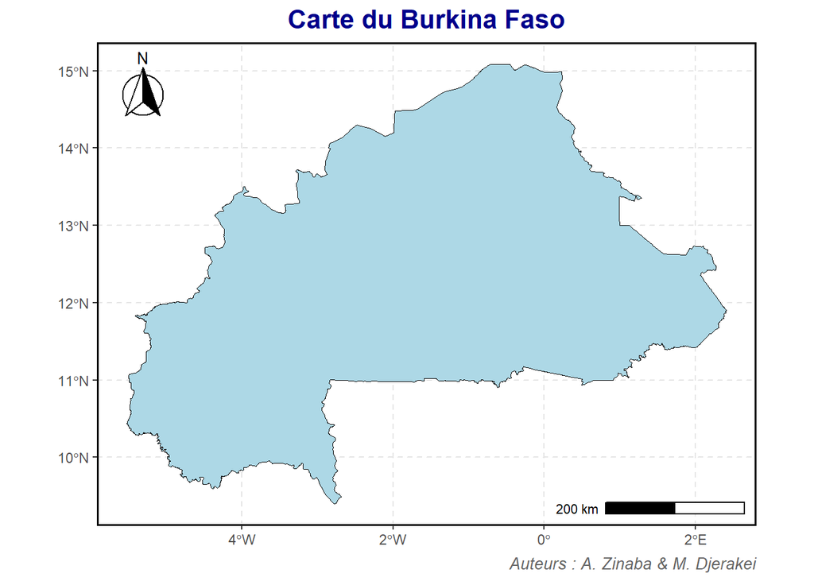

```r
# La carte avec ggplot2
carte_pays <- ggplot() +
  geom_sf(data = shapefile_pays, fill = "lightblue", color = "black", size = 0.4) +
  annotation_north_arrow(
    location = "tl", which_north = "true",
    style = north_arrow_fancy_orienteering() ) +
  annotation_scale(
    location = "br", width_hint = 0.3 ) +
  labs(
    title = "Carte du Burkina Faso",
    caption = "Auteurs : A. Zinaba & M. Djerakei") +
  theme_bw() +
  theme(
    plot.title = element_text(size = 16, face = "bold", color = "darkblue", hjust = 0.5),
    plot.subtitle = element_text(size = 12, color = "black", hjust = 0.5),
    plot.caption = element_text(size = 10, face = "italic", color = "gray40"),
    panel.border = element_rect(color = "black", fill = NA, size = 1),
    panel.grid.major = element_line(color = "gray90", linetype = "dashed"))

# Afficher la carte
carte_pays
```

#### Creation de la carte des regions du Burkina Faso, premier découpage administratif.

Nous créons une carte des régions du Burkina Faso en attribuant une couleur unique à chaque région, et affichons les noms des régions avec des éléments visuels comme une boussole et une échelle.

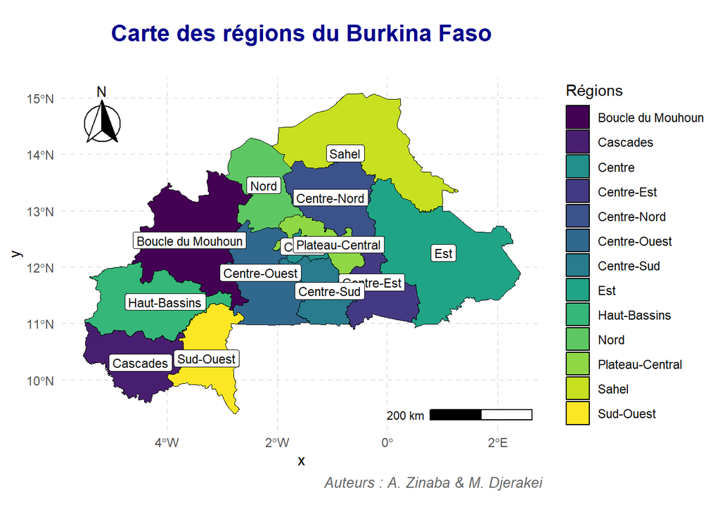

```r
# Génération d'une palette de couleurs unique pour chaque région
nb_regions <- length(unique(shapefile_regions$NAME_1))
palette_regions <- setNames(viridis_pal(option = "D")(nb_regions), unique(shapefile_regions$NAME_1))

# Création de  la carte
carte_regions <- ggplot() +
  # Remplissage des régions avec des couleurs uniques
  geom_sf(data = shapefile_regions, aes(fill = NAME_1), color = "black", size = 0.3) +

  # Ajout des noms des régions
  geom_sf_label(data = shapefile_regions, aes(label = NAME_1), color = "black", size = 3, fill = "white") +

  # Ajout d'une boussole en haut à gauche
  annotation_north_arrow(
    location = "tl", which_north = "true",
    style = north_arrow_fancy_orienteering() ) +
  annotation_scale(
    location = "br", width_hint = 0.3) +

  # Légendes
  labs(
    title = "Carte des régions du Burkina Faso",
    subtitle = "",
    caption = "Auteurs : A. Zinaba & M. Djerakei",
    fill = "Régions") +

  scale_fill_manual(values = palette_regions) +
  theme_minimal() +
  theme(
    plot.title = element_text(size = 16, face = "bold", color = "darkblue", hjust = 0.5),
    plot.subtitle = element_text(size = 12, color = "black", hjust = 0.5),
    plot.caption = element_text(size = 10, face = "italic", color = "gray40"),
    legend.position = "right",
    panel.grid.major = element_line(color = "gray90", linetype = "dashed"))

# Afficher la carte
carte_regions
```

#### Creation de la carte des provinces du Burkina Faso, deuxième decoupage administratif.

Nous créons une carte des provinces du Burkina Faso en utilisant ggplot2 et un fichier shapefile. Une couleur unique est attribué à chaque province via la palette viridis. Des étiquettes pour les noms des provinces, une boussole sont ajoutés.

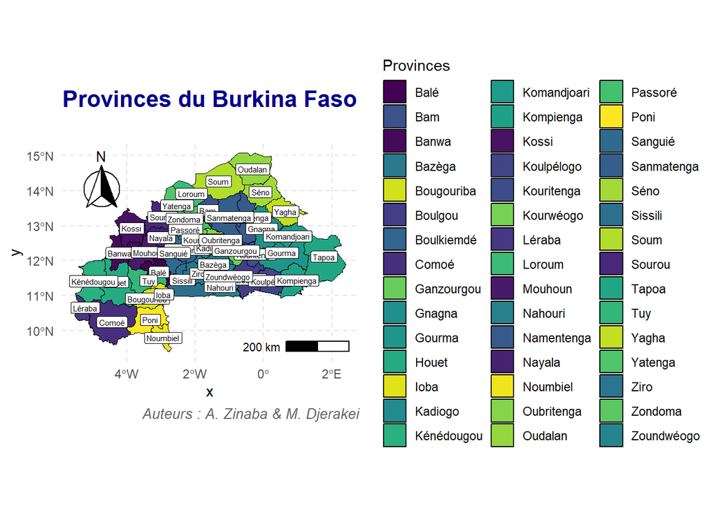

```r
# Une palette de couleurs unique pour chaque province
nb_provinces <- length(unique(shapefile_provinces$NAME_2))
palette_provinces <- setNames(viridis_pal(option = "D")(nb_provinces), unique(shapefile_provinces$NAME_2))

# Création de la carte avec ggplot2
carte_provinces <- ggplot() +
  geom_sf(data = shapefile_provinces, aes(fill = NAME_2), color = "black", size = 0.3) +

  # Ajout des noms des provinces
  geom_sf_label(data = shapefile_provinces, aes(label = NAME_2), color = "black", size = 2, fill = "white") +

  # Ajout d'une boussole en haut à gauche
  annotation_north_arrow(
    location = "tl", which_north = "true",
    style = north_arrow_fancy_orienteering()) +

  # Ajout d'une échelle en bas à droite
  annotation_scale(
    location = "br", width_hint = 0.3) +

  # Légende et titres
  labs(
    title = "Provinces du Burkina Faso",
    subtitle = "",
    caption = "Auteurs : A. Zinaba & M. Djerakei",
    fill = "Provinces") +

  # Palette de couleurs pour les provinces
  scale_fill_manual(values = palette_provinces) +
  theme_minimal() +
  theme(
    plot.title = element_text(size = 16, face = "bold", color = "darkblue", hjust = 0.5),
    plot.subtitle = element_text(size = 12, color = "black", hjust = 0.5),
    plot.caption = element_text(size = 10, face = "italic", color = "gray40"),
    legend.position = "right",
    panel.grid.major = element_line(color = "gray90", linetype = "dashed"))

# Afficher la carte
carte_provinces
```

#### Creation de la carte des communes troisieme decoupage adminitratif.

Nous créons une carte des communes du Burkina Faso, en les regroupant par région. Nous ajoutons une colonne “region” dans le shapefile pour associer chaque commune à sa région, puis génère une palette de couleurs unique pour chaque région pour une meilleure visibilité.

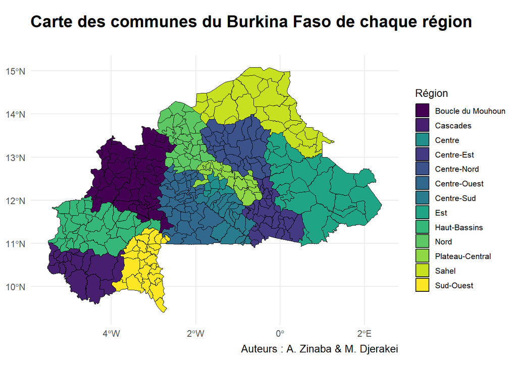

```r
# Ajouter une colonne pour le regroupement
shapefile_communes$region <- shapefile_communes$NAME_1  # Utiliser la colonne des régions

# Génération d'une palette de couleurs unique pour chaque région
palette_regions <- setNames(viridis(length(unique(shapefile_communes$region))), unique(shapefile_communes$region))

# Créons la carte avec un regroupement par région
carte_communes_regroupees <- ggplot(shapefile_communes) +
  geom_sf(aes(fill = region), color = "black", size = 0.1) + # Remplir avec la variable région
  scale_fill_manual(values = palette_regions, name = "Région") + # Utiliser la palette de couleurs générée
  labs(title = "Carte des communes du Burkina Faso de chaque région",
       subtitle = "",
       caption = "Auteurs : A. Zinaba & M. Djerakei") +
  theme_minimal() +
  theme(
    plot.title = element_text(size = 16, face = "bold"),
    plot.subtitle = element_text(size = 14),
    plot.caption = element_text(size = 10),
    legend.title = element_text(size = 10),
    legend.text = element_text(size = 8),
    legend.key.size = unit(0.5, "cm")
  )

carte_communes_regroupees
```

#### Conclusion

Ce document fournit une analyse géospatiale des données des ménages au Burkina Faso, en utilisant des cartes interactives pour visualiser les données à différents niveaux administratifs. Les cartes permettent de mieux comprendre la répartition des ménages, leurs caractéristiques, et les dynamiques de migration et de résidence. La deuxième partie du document se concentre sur la création de cartes administratives du Burkina Faso, en utilisant des fichiers shapefile pour représenter les différents niveaux administratifs.